# STAT5003_Assigment

STAT5003

Rayne Zhu 530551405, Shenglong Huang 480185790, Clark Xiong 490215441, chenghao xia 530774428, Tian Yang530220904, Ziqi Long 480057523

# 1 Overview

The dataset comes from the Behavioral Risk Factor Surveillance System (BRFSS), a health-related telephone survey, that collects data from U.S. residents about their life habits and risk behaviors regarding subjects’ health. BRFSS is a large health survey system that continuously completes more than 400,000 adult interviews each year. The dataset we will be using is the data from 2015.

The survey contains many health-related questions, which will be treated as attributes. The answers to each question are usually delivered as yes or no or not sure. In this analysis, we will use the data from 2015, to predict the attribute “TOLDHI2” as the target attribute. The corresponding question of “TOLDHI2” is “Have you EVER been told by a doctor, nurse, or another health professional that your blood cholesterol is high”. The answers are distributed to Yes, No, Don’t know, Refused. In this analysis, the distribution of the target attributes is only considers two classes: Yes and No, as a binary classification since the most of data belongs to these two classes. The original dataset has over 400k data and 330 attributes.

```r
library(tidyverse)
library(class)
library(reshape2)
library(cvTools)
library(rstanarm)
library(e1071)
library(caTools)
library(ggplot2)
library(caret)
library(dplyr)
library(randomForest)
library(pROC)
library(bnclassify)
library(Matrix)
library(ROCR)
library(glmnet)
library(readr)
library(foreach)
library(doParallel)
```

# 2 Data Preprocessing

```r
BRFS = read_csv("2015.csv", show_col_types = FALSE)
dim(BRFS)
```

```
## [1] 441456    330
```

```r
# Calculate the percentage of missing values for each attribute
missing_percentage <- sapply(BRFS, function(x) {
  round(sum(is.na(x)) / length(x) * 100, 3)
})

# Create a data frame from the missing_percentage vector for a nicer display
missing_percentage_df <- data.frame(Attribute = names(missing_percentage), MissingPercentage = missing_percentage)
missing_percentage_df_sorted <- missing_percentage_df[order(-missing_percentage_df$MissingPercentage), ]

# Print out the percentages in table format
# Comment out for redundant visuals in HTML file
# print(missing_percentage_df_sorted)
```

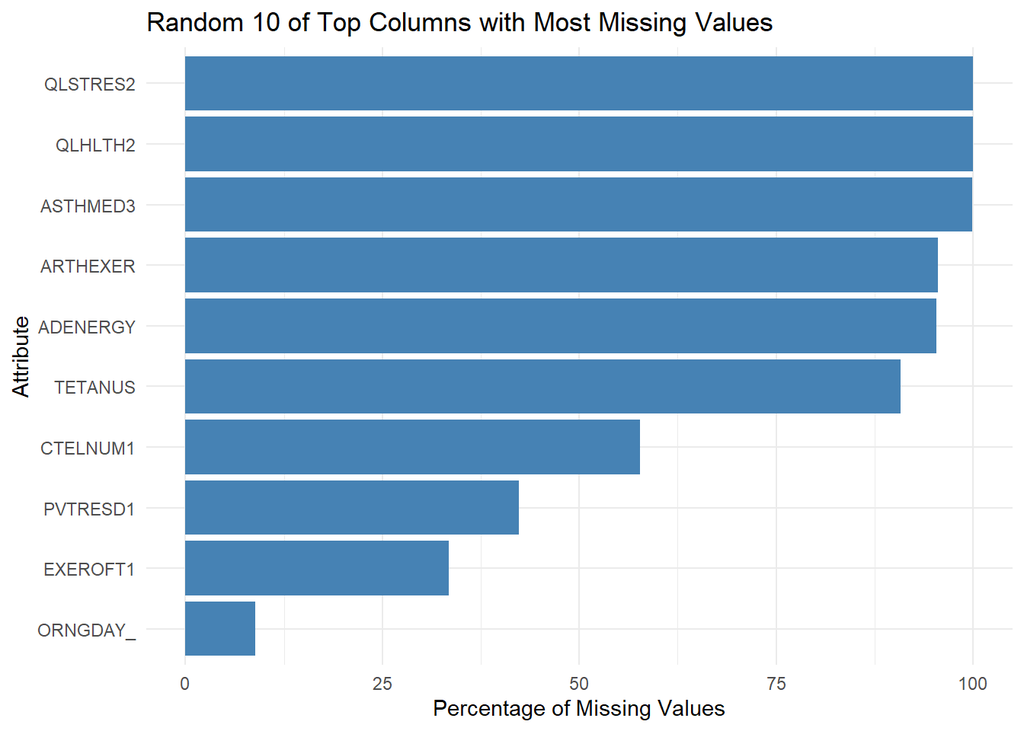

```r
# Select the top 50 columns
top_50 <- head(missing_percentage_df_sorted, 200)

# Randomly select 10 from these 150
set.seed(5003) # Setting a seed for reproducibility
random_10 <- top_50[sample(1:nrow(top_50), 10), ]

# Create the plot
ggplot(random_10, aes(x = reorder(Attribute, MissingPercentage), y = MissingPercentage)) +
  geom_bar(stat = "identity", fill = "steelblue") +
  coord_flip() +
  labs(x = "Attribute", y = "Percentage of Missing Values", title = "Random 10 of Top Columns with Most Missing Values") +
  theme_minimal()
```

The dataset contains a substantial number of missing values, which may pose significant challenges in subsequent modeling step. The initial step involves removing the rows with a high proportion of missing data. From the bar chart, instead of printing all columns, we randomly select from dataset to avoid visual redundancy in output, it is evident that certain variables exhibit complete absence of data.

## 2.1 Remove attributes based on percentage of missing

```r
# Identify attributes where the missing value percentage is greater than 30%
attributes_to_remove <- names(missing_percentage[missing_percentage > 30 & names(missing_percentage) != "MAXDRNKS"])

# Remove those attributes from the data frame
BRFS_cleaned <- BRFS[, !(names(BRFS) %in% attributes_to_remove)]

BRFS_cleaned <- BRFS_cleaned[ , -which(colnames(BRFS_cleaned) %in% c("_STATE", "FMONTH", "IDATE", "IMONTH", "IDAY", "IYEAR", "DISPCODE", "SEQNO", "_PSU"))]
```

The attributes with a missing value percentage greater than 30% are subsequently removed. Additionally, any attributes with ambiguous definitions are also eliminated to ensure the accuracy and interpretability of the results. After that, there are still 142 columns remaining.

## 2.2 Replace missing values for remaining variables

```r
# Function to calculate the mode
getMode <- function(v) {
  uniqv <- unique(v)
  uniqv[which.max(tabulate(match(v, uniqv)))]
}

for (col in names(BRFS_cleaned)) {
  # Check if there are missing values in the column
  if (sum(is.na(BRFS_cleaned[[col]])) > 0) {
    # Calculate the mode for the current column
    mode_value <- getMode(BRFS_cleaned[[col]][!is.na(BRFS_cleaned[[col]])])
    # Replace NA values with the mode value
    BRFS_cleaned[[col]][is.na(BRFS_cleaned[[col]])] <- mode_value
  }
}
```

```r
missing_percentage <- sapply(BRFS_cleaned, function(x) {
  round(sum(is.na(x)) / length(x) * 100, 3)
})

# Check after cleaning
all_zeros <- all(missing_percentage == 0)
all_zeros
```

```
## [1] TRUE
```

In this analysis, we’ve addressed the issue of missing data within the BRFS_cleaned dataset by employing a method that replaces any missing values in each column with the mode of that column. The mode was chosen because it maintains the statistical integrity of the data by aligning new entries with the most common existing values, thus minimizing the impact on the overall data distribution.

After implementing this imputation strategy, we verified the effectiveness of our approach by calculating the percentage of missing data in each column, ensuring that each is now zero percent. This confirmation ensures that the dataset is complete, allowing for more reliable and robust data analysis moving forward. The choice of the mode for imputation is particularly useful in categorical data where mean or median is not be applicable for categorical variable.

```r
# Comment out for faster knit
#write.csv(BRFS_cleaned, file = "BRFS_cleaned.csv", row.names = TRUE)
```

## 2.3 Feature selection

Feature selection is a pivotal step in data preprocessing, particularly when dealing with a dataset containing 143 columns, as in the case of our cleaned dataset. It reduces the risk of overfitting by eliminating irrelevant or redundant independent variables. Moreover, it can enhance the interpretability of the model, allowing for easier comprehension of key factors contributing to the classification.

Feature selection was conducted through a correlation-based filtering approach, starting with the calculation of a correlation matrix to measure the linear relationships among the dataset’s features. Focusing on ‘TOLDHI2’ as our target, we applied a predefined threshold to filter out relatively less irrelevant features. Specifically, we identified features with an absolute correlation coefficient above the threshold as significant. Those that have a moderate to strong linear association with the TOLDHI2 are likely to be informative predictors in a classification model.

```r
# Data reading
BRFS_cleaned = read_csv("BRFS_cleaned.csv", show_col_types = FALSE)
dim(BRFS_cleaned)
```

```
## [1] 276999    143
```

```r
# Remove all unkonwn answers
BRFS_cleaned <- subset(BRFS_cleaned, TOLDHI2 != 7 & TOLDHI2 != 9)

# Get important features that the correlation is above the threshold
cor_matrix <- cor(BRFS_cleaned[sapply(BRFS_cleaned, is.numeric)])

cholesterol_correlations <- cor_matrix["TOLDHI2", ]

significant_features <- cholesterol_correlations[abs(cholesterol_correlations) > 0.1 & names(cholesterol_correlations) != "TOLDHI2"]
```

```r
# List of columns you want to read
columns_to_read <- c( "TOLDHI2", "GENHLTH", "CHECKUP1", "BPHIGH4", "BLOODCHO", "HAVARTH3", "DIABETE3", "MARITAL", "EMPLOY1", "CHILDREN", "PNEUVAC3", "_CHISPNC", "_HCVU651", "_RFHYPE5", "_CHOLCHK", "_MICHD", "_DRDXAR1", "_AGEG5YR", "_BMI5", "_SMOKER3", "MAXDRNKS", "CVDSTRK3", "_TOTINDA", "_FRTLT1", "_VEGLT1", "HLTHPLN1", "MEDCOST", "MENTHLTH", 'SEX')
# Read the specified columns from the CSV file
BRFS_cleaned <- read_csv("BRFS_cleaned.csv", col_select = columns_to_read, show_col_types = FALSE)
BRFS_cleaned <- BRFS_cleaned %>%
  mutate(across(-c("_BMI5", "MAXDRNKS", "MENTHLTH", "CHILDREN"), factor))
column_types <- sapply(BRFS_cleaned, class)
```

Remove instances that gives unknown answers

```r
remove_7_9 <- c("TOLDHI2", "GENHLTH", "CHECKUP1", "BPHIGH4", "BLOODCHO", "HAVARTH3", "DIABETE3", "PNEUVAC3", "CVDSTRK3", "HLTHPLN1", "MEDCOST")
remove_9 <- c("MARITAL", "EMPLOY1", "_CHISPNC", "_HCVU651", "_RFHYPE5", "_CHOLCHK", "_SMOKER3", "_TOTINDA", "_FRTLT1", "_VEGLT1")
remove_88_99 <- "CHILDREN"
remove_14 <- "_AGEG5YR"
remove_77_99 <- c("MAXDRNKS", "MENTHLTH")

# Apply the filter conditions using the lists
for(col in remove_7_9) {
  BRFS_cleaned <- BRFS_cleaned[!BRFS_cleaned[[col]] %in% c(7, 9), ]
}

for(col in remove_9) {
  BRFS_cleaned <- BRFS_cleaned[!BRFS_cleaned[[col]] %in% c(9), ]
}

BRFS_cleaned <- BRFS_cleaned[!BRFS_cleaned[["CHILDREN"]] %in% c(88, 99), ]

BRFS_cleaned <- BRFS_cleaned[!BRFS_cleaned[["_AGEG5YR"]] %in% c(14), ]

# value 88 represents None in MENTHLTH
BRFS_cleaned$MENTHLTH[BRFS_cleaned$MENTHLTH == 88] <- 0

for(col in c("MAXDRNKS", "MENTHLTH")) {
BRFS_cleaned <- BRFS_cleaned[!BRFS_cleaned[[col]] %in% c(77, 99), ]
}
```

```r
BRFS_filtered <- read_csv("BRFS_feature_filtered.csv", show_col_types = FALSE)
```

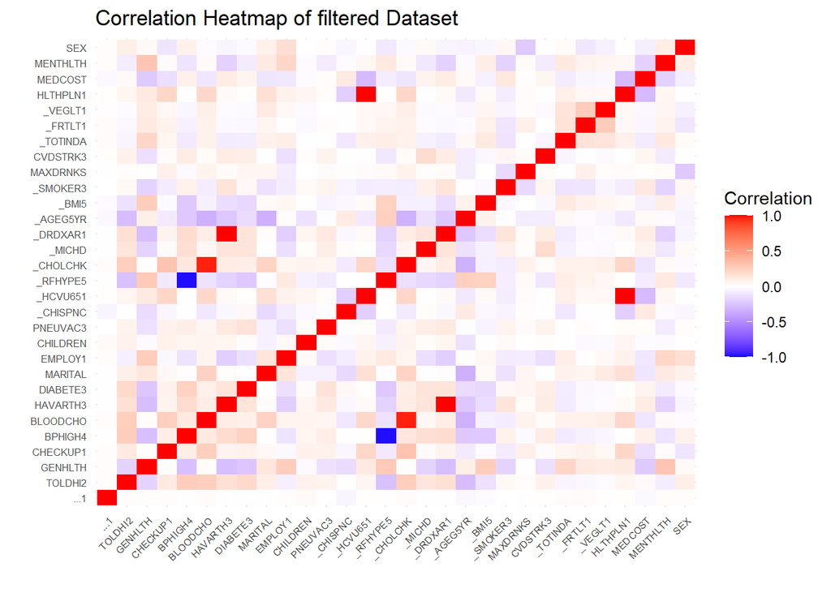

```r
cor_matrix <- cor(BRFS_filtered, use = "complete.obs")  # Assuming 'BRFS_filtered' is numeric

# Melt the correlation matrix into a long format
cor_data <- melt(cor_matrix)

# Create the heatmap
ggplot(data = cor_data, aes(x = Var1, y = Var2, fill = value)) +
  geom_tile() + # Use geom_tile for heatmap representation
  scale_fill_gradient2(low = "blue", high = "red", mid = "white",
                       midpoint = 0, limit = c(-1,1), space = "Lab",
                       name="Correlation") +
  theme_minimal() +
  theme(axis.text.x = element_text(angle = 45, vjust = 1, hjust = 1, size = 6), axis.text.y = element_text(size = 6) ) +
  labs(x = "", y = "", title = "Correlation Heatmap of filtered Dataset")
```

In the figure, we can see that _CHOLCHK and BLOODCHO, _DRDXAR1 and HAVARTH3, HLTHPLN1 and _HCVU651 all have strong positive correlation. This is because _CHOLCHK and BLOODCHO is both related to cholesterol checks, _DRDXAR1 and HAVARTH3 both include arthritis, HLTHPLN1 and _HCVU651 are both indicators of healthcare coverage.

We also notice from the correlation figure that factor _RFHYPE5 and factor BPHIGH4 have strong negative correlations. The reason is that these two factors is all related to high blood pressure, but with slightly difference, BPHIGH4 also consider the high blood pressure during pregnancy which is usually caused by pre-eclampsia and should be a separate condition from chronic hypertension. Moreover in _RFHYPE5, 1 represents “No” and 2 represents “Yes”, but in _RFHYPE5 1 and 2 represents “Yes” and 3 represents “No”, so this reverse coding explains strong negative correlation between the two factors.

```r
BRFS_filtered <- BRFS_filtered %>%
  mutate(across(-c("_BMI5", "MAXDRNKS", "MENTHLTH", "CHILDREN"), factor))

column_types <- sapply(BRFS_filtered, class)
```

## 2.4 PCA

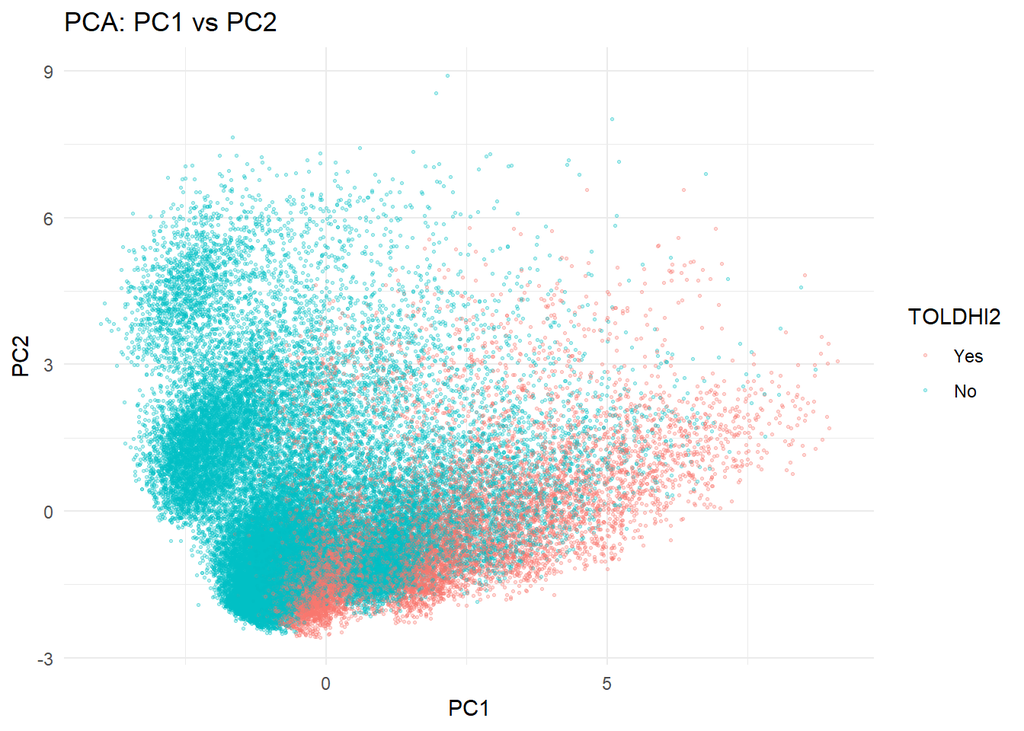

```r
numericData <- data.frame(lapply(BRFS_filtered, as.numeric))

# Assuming 'TOLDHI2' is a factor for grouping in the visualizations
groupingVariable <- as.factor(BRFS_filtered$TOLDHI2)

# Scale the numeric data before PCA
numericData <- scale(numericData)

BRFSPc <- prcomp(numericData, scale. = TRUE)

BRFSDf <- data.frame(PC1 = BRFSPc$x[,1],
                            PC2 = BRFSPc$x[,2],
                            PC3 = BRFSPc$x[,3],
                            TOLDHI2 = groupingVariable)

ggplot(BRFSDf, aes(x = PC1, y = PC2, colour = factor(TOLDHI2, levels = c(1,2), labels = c("Yes", "No")))) +
      geom_point(size=0.5, alpha = 0.3) +
      theme_minimal() +
      labs(title = "PCA: PC1 vs PC2", col="TOLDHI2")
```

# 3 Classification methods

```r
data <- read.csv('BRFS_feature_filtered.csv')
data <- data[,-1]
data$TOLDHI2 <- ifelse(data$TOLDHI2 == 2, 0, 1)
data$TOLDHI2 <- as.factor(data$TOLDHI2)

# Splitting the data into training (60%), validation (20%), and test (20%) sets
set.seed(5003)  # for reproducibility
split <- createDataPartition(data$TOLDHI2, p=0.6, list=FALSE)
training <- data[split,]
temp <- data[-split,]
split2 <- createDataPartition(temp$TOLDHI2, p=0.5, list=FALSE)
validation <- temp[split2,]
test <- temp[-split2,]
```

## 3.1 Naive Bayes

Bayesian networks are a type of probabilistic graphical model that represent the joint conditional probability distribution of a set of variables.

### 3.1.1 Data processing

Converts all columns except “X_BMI5”, “MAXDRNKS”, “MENTHLTH”, and “CHILDREN” into factors. The modified data will be categorical data. Removes a column named ‘X’ from the dataset.

Numerical variables “X_BMI5”, “MAXDRNKS”, “MENTHLTH”, and “CHILDREN” are all divided into quartiles. The labels = FALSE option returns categories as integer numbers (1 through 4). After segmenting these variables into categories, they were converted from categorical integer variables into factor variables.

```r
categorize <- function(data){
  quantile.cut <- function(x){
    cut(x, breaks = unique(quantile(x, probs = 0:4/4, na.rm = T)), labels = F, include.lowest = T, right = F)
  }
  return(data %>%
           mutate(
             across(c("X_BMI5", "MAXDRNKS", "MENTHLTH", "CHILDREN"), quantile.cut),
             across(!where(is.factor), as.factor)
             )
    )
}
training.categorized <- categorize(training)
validation.categorized <- categorize(validation)
test.categorized <- categorize(test)
trainfull.categorized <- training.categorized %>% bind_rows(validation.categorized)
```

### 3.1.2 Model Selection

We employ the Hill-Climbing Super-Parent Tree Augmented Naive Bayes (TAN-HCSP) model and utilize train/validation splitting to select the best parameters for the model. The selection process is optimized in parallel.

```r
registerDoParallel(cores = detectCores())
nb.params <- expand.grid(list(epsilon = 10^seq(-5, -2, length.out = 5),
                              smooth = 10^seq(-3, -1, length.out = 5),
                              k = 5,
                              smooth.final = 0.5
                              ))

nb.results <- foreach(i = 1:nrow(nb.params), .packages = "bnclassify", .combine = rbind) %dopar% {
  set.seed(5003)
  nb <- tan_hcsp("TOLDHI2", training.categorized,
                 nb.params$k[i],
                 epsilon = nb.params$epsilon[i],
                 smooth = nb.params$smooth[i])
  nb <- lp(nb, training.categorized, smooth = nb.params$smooth.final[i])
  predictions <- predict(nb, validation.categorized)
  cm <- table(predictions, validation.categorized$TOLDHI2)
  accuracy <- sum(diag(cm))/sum(cm)
  list(model = nb, accuracy = accuracy)
} %>% as.data.frame() %>% mutate(accuracy = as.numeric(accuracy)) %>% cbind(nb.params)
nb.best.result <- max(nb.results$accuracy)
nb.best.model <- nb.results$model[which.max(nb.results$accuracy)]
nb.best.params <- nb.results[which.max(nb.results$accuracy),]
nb.best.result
```

```
## [1] 0.800222
```

### 3.1.3 Naive Bayes cv score

```r
set.seed(5003)
nb.cv.score <- cv(nb.best.model, trainfull.categorized, 5)
nb.cv.score
```

```
## result.11
## 0.7921971
```

### 3.1.4 Naive Bayes evaluation

```r
set.seed(5003)
nb.model.final <- tan_hcsp("TOLDHI2", trainfull.categorized, nb.best.params$k, epsilon = nb.best.params$epsilon, smooth = nb.best.params$smooth)
nb.model.final <- lp(nb.model.final, trainfull.categorized, smooth = nb.best.params$smooth.final)
nb.predictions <- predict(nb.model.final, test.categorized)
nb.result <- confusionMatrix(nb.predictions, test.categorized$TOLDHI2)
nb.result
```

```
## Confusion Matrix and Statistics
##
##           Reference
## Prediction    0    1
##          0 6415 1287
##          1  596  711
##
##                Accuracy : 0.791
##                  95% CI : (0.7824, 0.7993)
##     No Information Rate : 0.7782
##     P-Value [Acc > NIR] : 0.00174
##
##                   Kappa : 0.3091
##
##  Mcnemar's Test P-Value : < 2e-16
##
##             Sensitivity : 0.9150
##             Specificity : 0.3559
##          Pos Pred Value : 0.8329
##          Neg Pred Value : 0.5440
##              Prevalence : 0.7782
##          Detection Rate : 0.7121
##    Detection Prevalence : 0.8549
##       Balanced Accuracy : 0.6354
##
##        'Positive' Class : 0
##
```

```r
nb.result$byClass
```

```
##          Sensitivity          Specificity       Pos Pred Value
##            0.9149907            0.3558559            0.8329005
##       Neg Pred Value            Precision               Recall
##            0.5439939            0.8329005            0.9149907
##                   F1           Prevalence       Detection Rate
##            0.8720179            0.7782218            0.7120657
## Detection Prevalence    Balanced Accuracy
##            0.8549229            0.6354233
```

```r
nb.pred.prob <- predict(nb.model.final, newdata = test.categorized, prob = TRUE)[,2]
nb.roc <- roc(test.categorized$TOLDHI2, nb.pred.prob)
```

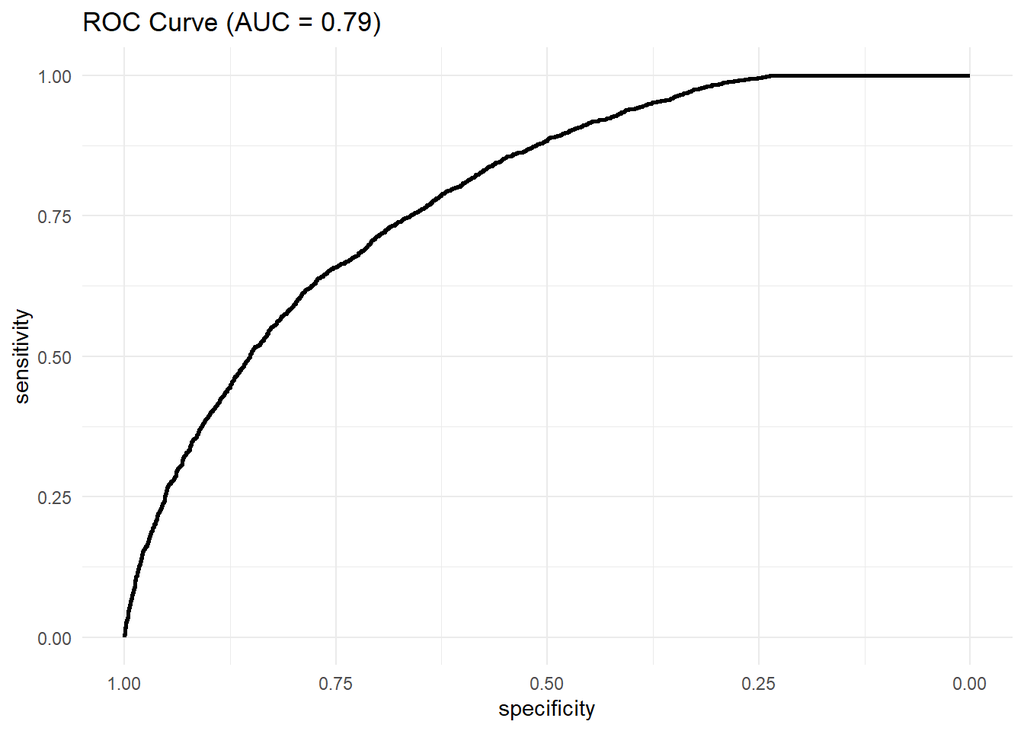

```r
ggroc(nb.roc, size = 1) + ggtitle(sprintf("ROC Curve (AUC = %.2f)", auc(nb.roc))) + theme_minimal()
```

The evaluation is conducted on the testing dataset.

The ROC curve itself shows the trade-off between sensitivity and specificity for different thresholds. An AUC of 0.79 is quite good, showing that your classifier has a high degree of separability between two classes. The curve rises quickly toward the top-left corner, indicating a good performance on class 0, and relatively low accuracy rate for class 1.

## 3.2 SVM

Support Vector Machines (SVM) are another effective machine learning method, particularly suited for classification tasks like predicting high blood cholesterol. An SVM works by finding the hyperplane that best divides a dataset into classes, maximizing the margin between different classes in the feature space. It can perform well in high-dimensional spaces, which is beneficial when dealing with complex health data sets.

```r
# Train SVM model
train_control <- trainControl(method = "cv", number = 5)

model_svm <- train(
  TOLDHI2 ~ .,
  data = training,
  method = "svmLinear",
  trControl = train_control,
  tuneLength = 10
)
print(model_svm)
```

```
## Support Vector Machines with Linear Kernel
##
## 27029 samples
##    28 predictor
##     2 classes: '0', '1'
##
## No pre-processing
## Resampling: Cross-Validated (5 fold)
## Summary of sample sizes: 21623, 21623, 21624, 21622, 21624
## Resampling results:
##
##   Accuracy   Kappa
##   0.7915938  0.1973156
##
## Tuning parameter 'C' was held constant at a value of 1
```

### 3.2.1 Cross-validation using the validation set

```r
predictions <- predict(model_svm, validation)
confusionMatrix(predictions, validation$TOLDHI2)
```

```
## Confusion Matrix and Statistics
##
##           Reference
## Prediction    0    1
##          0 6804 1655
##          1  207  344
##
##                Accuracy : 0.7933
##                  95% CI : (0.7848, 0.8017)
##     No Information Rate : 0.7781
##     P-Value [Acc > NIR] : 0.0002436
##
##                   Kappa : 0.1924
##
##  Mcnemar's Test P-Value : < 2.2e-16
##
##             Sensitivity : 0.9705
##             Specificity : 0.1721
##          Pos Pred Value : 0.8044
##          Neg Pred Value : 0.6243
##              Prevalence : 0.7781
##          Detection Rate : 0.7552
##    Detection Prevalence : 0.9388
##       Balanced Accuracy : 0.5713
##
##        'Positive' Class : 0
##
```

### 3.2.2 Final evaluation on the test set

```r
final_predictions <- predict(model_svm, test)
final_results <- confusionMatrix(final_predictions, test$TOLDHI2)
print(final_results)
```

```
## Confusion Matrix and Statistics
##
##           Reference
## Prediction    0    1
##          0 6790 1672
##          1  221  326
##
##                Accuracy : 0.7899
##                  95% CI : (0.7813, 0.7983)
##     No Information Rate : 0.7782
##     P-Value [Acc > NIR] : 0.003853
##
##                   Kappa : 0.1778
##
##  Mcnemar's Test P-Value : < 2.2e-16
##
##             Sensitivity : 0.9685
##             Specificity : 0.1632
##          Pos Pred Value : 0.8024
##          Neg Pred Value : 0.5960
##              Prevalence : 0.7782
##          Detection Rate : 0.7537
##    Detection Prevalence : 0.9393
##       Balanced Accuracy : 0.5658
##
##        'Positive' Class : 0
##
```

```r
# Detailed accuracy by class
print(final_results$byClass)
```

```
##          Sensitivity          Specificity       Pos Pred Value
##            0.9684781            0.1631632            0.8024108
##       Neg Pred Value            Precision               Recall
##            0.5959781            0.8024108            0.9684781
##                   F1           Prevalence       Detection Rate
##            0.8776579            0.7782218            0.7536908
## Detection Prevalence    Balanced Accuracy
##            0.9392829            0.5658206
```

### 3.2.3 SVM ROC curve

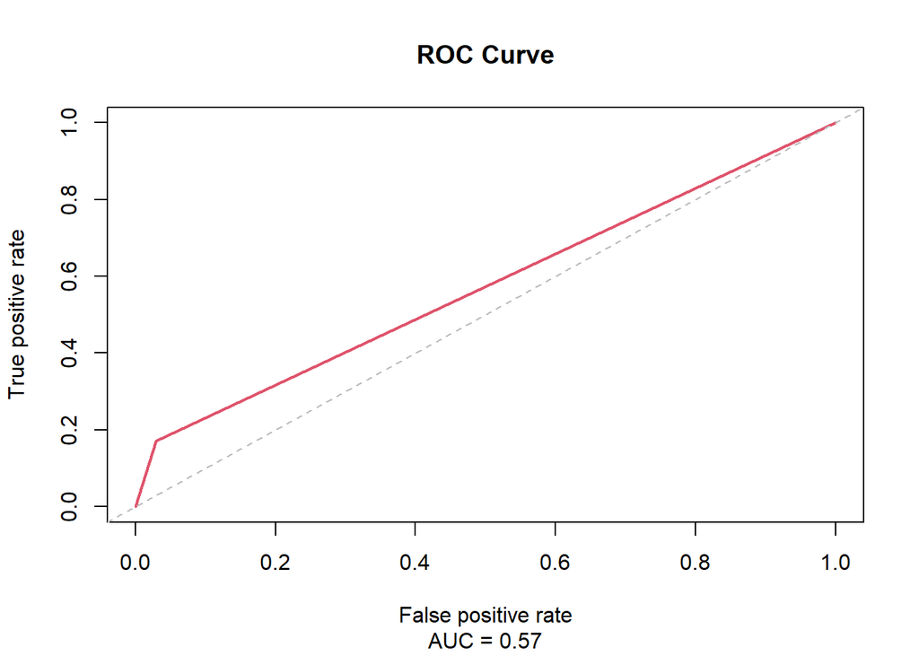

```r
pred_obj <- prediction(as.numeric(predictions), as.numeric(validation$TOLDHI2))
perf <- performance(pred_obj, "tpr", "fpr")
plot(perf, col=2, lwd=2, main="ROC Curve", sub=sprintf("AUC = %.2f", performance(pred_obj, "auc")@y.values[[1]]))
abline(a=0, b=1, lty=2, col="gray")
```

## 3.3 Naive Bayes

```r
categorize <- function(data){
  quantile.cut <- function(x){
    cut(x, breaks = unique(quantile(x, probs = 0:4/4, na.rm = T)), labels = F, include.lowest = T, right = F)
  }
  return(data %>%
           mutate(
             across(c("X_BMI5", "MAXDRNKS", "MENTHLTH", "CHILDREN"), quantile.cut),
             across(!where(is.factor), as.factor)
             )
    )
}
training.categorized <- categorize(training)
validation.categorized <- categorize(validation)
test.categorized <- categorize(test)
trainfull.categorized <- training.categorized %>% bind_rows(validation.categorized)
```

### 3.3.1 Optimizing by Using Parallel Processing

```r
registerDoParallel(cores = detectCores())
nb.params <- expand.grid(list(epsilon = 10^seq(-5, -2, length.out = 5),
                              smooth = 10^seq(-3, -1, length.out = 5),
                              k = 5,
                              smooth.final = 0.5
                              ))

nb.results <- foreach(i = 1:nrow(nb.params), .packages = "bnclassify", .combine = rbind) %dopar% {
  set.seed(5003)
  nb <- tan_hcsp("TOLDHI2", training.categorized,
                 nb.params$k[i],
                 epsilon = nb.params$epsilon[i],
                 smooth = nb.params$smooth[i])
  nb <- lp(nb, training.categorized, smooth = nb.params$smooth.final[i])
  predictions <- predict(nb, validation.categorized)
  cm <- table(predictions, validation.categorized$TOLDHI2)
  accuracy <- sum(diag(cm))/sum(cm)
  list(model = nb, accuracy = accuracy)
} %>% as.data.frame() %>% mutate(accuracy = as.numeric(accuracy)) %>% cbind(nb.params)
nb.best.result <- max(nb.results$accuracy)
nb.best.model <- nb.results$model[which.max(nb.results$accuracy)]
nb.best.params <- nb.results[which.max(nb.results$accuracy),]
nb.best.result
```

```
## [1] 0.800222
```

### 3.3.2 Naive Bayes cv score

```r
set.seed(5003)
nb.cv.score <- cv(nb.best.model, trainfull.categorized, 5)
nb.cv.score
```

```
## result.11
## 0.7921971
```

### 3.3.3 Naive Bayes evaluation

```r
set.seed(5003)
nb.model.final <- tan_hcsp("TOLDHI2", trainfull.categorized, nb.best.params$k, epsilon = nb.best.params$epsilon, smooth = nb.best.params$smooth)
nb.model.final <- lp(nb.model.final, trainfull.categorized, smooth = nb.best.params$smooth.final)
nb.predictions <- predict(nb.model.final, test.categorized)
nb.result <- confusionMatrix(nb.predictions, test.categorized$TOLDHI2)
nb.result
```

```
## Confusion Matrix and Statistics
##
##           Reference
## Prediction    0    1
##          0 6415 1287
##          1  596  711
##
##                Accuracy : 0.791
##                  95% CI : (0.7824, 0.7993)
##     No Information Rate : 0.7782
##     P-Value [Acc > NIR] : 0.00174
##
##                   Kappa : 0.3091
##
##  Mcnemar's Test P-Value : < 2e-16
##
##             Sensitivity : 0.9150
##             Specificity : 0.3559
##          Pos Pred Value : 0.8329
##          Neg Pred Value : 0.5440
##              Prevalence : 0.7782
##          Detection Rate : 0.7121
##    Detection Prevalence : 0.8549
##       Balanced Accuracy : 0.6354
##
##        'Positive' Class : 0
##
```

```r
nb.result$byClass
```

```
##          Sensitivity          Specificity       Pos Pred Value
##            0.9149907            0.3558559            0.8329005
##       Neg Pred Value            Precision               Recall
##            0.5439939            0.8329005            0.9149907
##                   F1           Prevalence       Detection Rate
##            0.8720179            0.7782218            0.7120657
## Detection Prevalence    Balanced Accuracy
##            0.8549229            0.6354233
```

## 3.4 Logistic Regression

```r
# Train the model with Lasso Regression
model_lasso <- train(
  TOLDHI2 ~ .,
  data = training,
  method = "glmnet",
  family = "binomial",
)
```

In the train() function, the bootstrapping appears to be used by default. The“glmnet”indicates that the model is using the generalized linear model with elastic net regularization. The predicted model is logistic model so family = “binomial”. The logistic regression includes lasso regression using penalty L1 and ridge regression using penalty L2. The L1 penalty removes some features by reducing coefficients of features to exact zero. The model will be simplified. The L2 penalty shrinks the coefficients closed to zero but notexactly zero. All features are kept but some coefficients are lower down. The model utilizes the elastic net regulation which is the balanced option combining of the penalty L1 and L2.

### 3.4.1 model summary

```r
print(model_lasso)
```

```
## glmnet
##
## 27029 samples
##    28 predictor
##     2 classes: '0', '1'
##
## No pre-processing
## Resampling: Bootstrapped (25 reps)
## Summary of sample sizes: 27029, 27029, 27029, 27029, 27029, 27029, ...
## Resampling results across tuning parameters:
##
##   alpha  lambda        Accuracy   Kappa
##   0.10   0.0002346113  0.8022309  0.2812114
##   0.10   0.0023461129  0.8021182  0.2782574
##   0.10   0.0234611289  0.8019161  0.2585329
##   0.55   0.0002346113  0.8022232  0.2808907
##   0.55   0.0023461129  0.8021778  0.2760646
##   0.55   0.0234611289  0.7993744  0.2216429
##   1.00   0.0002346113  0.8022469  0.2806497
##   1.00   0.0023461129  0.8020891  0.2727757
##   1.00   0.0234611289  0.7954901  0.1759405
##
## Accuracy was used to select the optimal model using the largest value.
## The final values used for the model were alpha = 1 and lambda = 0.0002346113.
```

### 3.4.2 Final Evaluation

```r
predict_test=predict(model_lasso, test)
results <- confusionMatrix(predict_test, test$TOLDHI2)
print(results)
```

```
## Confusion Matrix and Statistics
##
##           Reference
## Prediction    0    1
##          0 6690 1496
##          1  321  502
##
##                Accuracy : 0.7983
##                  95% CI : (0.7899, 0.8066)
##     No Information Rate : 0.7782
##     P-Value [Acc > NIR] : 1.858e-06
##
##                   Kappa : 0.2602
##
##  Mcnemar's Test P-Value : < 2.2e-16
##
##             Sensitivity : 0.9542
##             Specificity : 0.2513
##          Pos Pred Value : 0.8172
##          Neg Pred Value : 0.6100
##              Prevalence : 0.7782
##          Detection Rate : 0.7426
##    Detection Prevalence : 0.9086
##       Balanced Accuracy : 0.6027
##
##        'Positive' Class : 0
##
```

```r
print(results$byClass)
```

```
##          Sensitivity          Specificity       Pos Pred Value
##            0.9542148            0.2512513            0.8172490
##       Neg Pred Value            Precision               Recall
##            0.6099635            0.8172490            0.9542148
##                   F1           Prevalence       Detection Rate
##            0.8804369            0.7782218            0.7425907
## Detection Prevalence    Balanced Accuracy
##            0.9086469            0.6027330
```

### 3.4.3 cross validation on validation dataset

```r
train_control <- trainControl(
  method = "cv",
  number = 5,
  savePredictions = "final"
)

model_cv <- train(
  TOLDHI2 ~ .,
  data = training,
  method = "glmnet",
  family = "binomial",
  trControl = train_control,
  tuneLength = 10
)

# Print model summary
print(model_cv)
```

```
## glmnet
##
## 27029 samples
##    28 predictor
##     2 classes: '0', '1'
##
## No pre-processing
## Resampling: Cross-Validated (5 fold)
## Summary of sample sizes: 21623, 21623, 21624, 21623, 21623
## Resampling results across tuning parameters:
##
##   alpha  lambda        Accuracy   Kappa
##   0.1    5.419825e-05  0.8023974  0.28013948
##   0.1    1.252050e-04  0.8023974  0.28013948
##   0.1    2.892398e-04  0.8022494  0.27916866
##   0.1    6.681814e-04  0.8023234  0.27921897
##   0.1    1.543586e-03  0.8022864  0.27858986
##   0.1    3.565883e-03  0.8024714  0.27704776
##   0.1    8.237652e-03  0.8020274  0.27113732
##   0.1    1.903004e-02  0.8018794  0.26038028
##   0.1    4.396187e-02  0.8011395  0.23820207
##   0.1    1.015576e-01  0.7963668  0.17670406
##   0.2    5.419825e-05  0.8023974  0.28013948
##   0.2    1.252050e-04  0.8023604  0.27995183
##   0.2    2.892398e-04  0.8021384  0.27870922
##   0.2    6.681814e-04  0.8022864  0.27892198
##   0.2    1.543586e-03  0.8024714  0.27878084
##   0.2    3.565883e-03  0.8024344  0.27642470
##   0.2    8.237652e-03  0.8023234  0.27032842
##   0.2    1.903004e-02  0.8015464  0.25541567
##   0.2    4.396187e-02  0.7998445  0.22051002
##   0.2    1.015576e-01  0.7921121  0.13217277
##   0.3    5.419825e-05  0.8023604  0.27995183
##   0.3    1.252050e-04  0.8022864  0.27957408
##   0.3    2.892398e-04  0.8021754  0.27868042
##   0.3    6.681814e-04  0.8022864  0.27892085
##   0.3    1.543586e-03  0.8024344  0.27827280
##   0.3    3.565883e-03  0.8025824  0.27586424
##   0.3    8.237652e-03  0.8016204  0.26534147
##   0.3    1.903004e-02  0.8015464  0.24996173
```

[output cut: 60 more lines]

```
##   0.9    4.396187e-02  0.7864516  0.07654572
##   0.9    1.015576e-01  0.7781642  0.00000000
##   1.0    5.419825e-05  0.8022124  0.27887034
##   1.0    1.252050e-04  0.8021754  0.27878872
##   1.0    2.892398e-04  0.8022864  0.27935559
##   1.0    6.681814e-04  0.8023604  0.27810854
##   1.0    1.543586e-03  0.8029153  0.27791048
##   1.0    3.565883e-03  0.8019164  0.26765288
##   1.0    8.237652e-03  0.8013985  0.25069287
##   1.0    1.903004e-02  0.7978098  0.19965925
##   1.0    4.396187e-02  0.7843428  0.05373004
##   1.0    1.015576e-01  0.7781642  0.00000000
##
## Accuracy was used to select the optimal model using the largest value.
## The final values used for the model were alpha = 1 and lambda = 0.001543586.
```

```r
predictions_log <- predict(model_cv, validation)
confusionMatrix(predictions_log, validation$TOLDHI2)
```

```
## Confusion Matrix and Statistics
##
##           Reference
## Prediction    0    1
##          0 6701 1465
##          1  310  534
##
##                Accuracy : 0.803
##                  95% CI : (0.7946, 0.8112)
##     No Information Rate : 0.7781
##     P-Value [Acc > NIR] : 4.613e-09
##
##                   Kappa : 0.2809
##
##  Mcnemar's Test P-Value : < 2.2e-16
##
##             Sensitivity : 0.9558
##             Specificity : 0.2671
##          Pos Pred Value : 0.8206
##          Neg Pred Value : 0.6327
##              Prevalence : 0.7781
##          Detection Rate : 0.7437
##    Detection Prevalence : 0.9063
##       Balanced Accuracy : 0.6115
##
##        'Positive' Class : 0
##
```

### 3.4.4 Final evaluation on the test set

```r
final_predictions <- predict(model_cv, test)
final_results <- confusionMatrix(final_predictions, test$TOLDHI2)
print(final_results)
```

```
## Confusion Matrix and Statistics
##
##           Reference
## Prediction    0    1
##          0 6699 1508
##          1  312  490
##
##                Accuracy : 0.798
##                  95% CI : (0.7895, 0.8062)
##     No Information Rate : 0.7782
##     P-Value [Acc > NIR] : 2.697e-06
##
##                   Kappa : 0.2554
##
##  Mcnemar's Test P-Value : < 2.2e-16
##
##             Sensitivity : 0.9555
##             Specificity : 0.2452
##          Pos Pred Value : 0.8163
##          Neg Pred Value : 0.6110
##              Prevalence : 0.7782
##          Detection Rate : 0.7436
##    Detection Prevalence : 0.9110
##       Balanced Accuracy : 0.6004
##
##        'Positive' Class : 0
##
```

### 3.4.5 Detailed accuracy by class

```r
print(final_results$byClass)
```

```
##          Sensitivity          Specificity       Pos Pred Value
##            0.9554985            0.2452452            0.8162544
##       Neg Pred Value            Precision               Recall
##            0.6109726            0.8162544            0.9554985
##                   F1           Prevalence       Detection Rate
##            0.8804048            0.7782218            0.7435897
## Detection Prevalence    Balanced Accuracy
##            0.9109779            0.6003719
```

### 3.4.6 ROC curve

```r
# Calculate ROC data
roc_data <- roc(response = test$TOLDHI2, predictor = as.numeric(final_predictions))
```

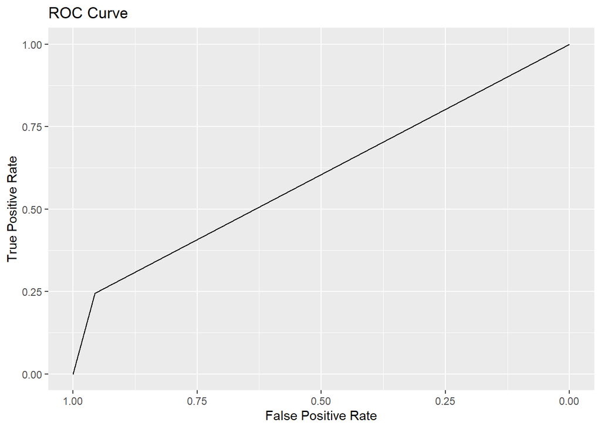

```r
# Plot ROC curve
ggroc(roc_data) +
  ggtitle("ROC Curve") +
  xlab("False Positive Rate") +
  ylab("True Positive Rate")
```

Except the summary of the values from model predictions, the ROC illustrates the trade-off between the True Positive Rate (Sensitivity) and the False Positive Rate. The initial sharp rise is promising as it indicates the model’s effectiveness at achieving high sensitivity with low false positives at certain thresholds. However, it becomes almost a 45-degree angle towards the end. It means the model performance is not much different as a random guessing. The point on “knee” of the curve could be the further investigation since the model performance diminishing at that point.

## 3.5 RF Model training

The Random Forest model is a powerful machine learning technique that can be used for classification tasks. In the following step we will use it to predict whether an individual has high blood cholesterol. This method involves constructing multiple decision trees during training, and for each input, it outputs the class that is the mode of the classes predicted by all the trees. In the context of predicting high blood cholesterol, the Random Forest model analyzes features related to each patient, then aggregates the predictions from all the decision trees to determine the most likely classification—whether a subject has high cholesterol or not. Random Forest model is used here due to its ability to handle large data sets with numerous variables. It can also manage unbalanced data and reduce the risk of over fitting by fine-tuning the parameters.

```r
set.seed(5003)
BRFS.rf <- randomForest(TOLDHI2 ~ ., data = training)
predictions <- predict(BRFS.rf, validation)

print(BRFS.rf)
```

```
##
## Call:
##  randomForest(formula = TOLDHI2 ~ ., data = training)
##                Type of random forest: classification
##                      Number of trees: 500
## No. of variables tried at each split: 5
##
##         OOB estimate of  error rate: 20.13%
## Confusion matrix:
##       0    1 class.error
## 0 19971 1062  0.05049208
## 1  4378 1618  0.73015344
```

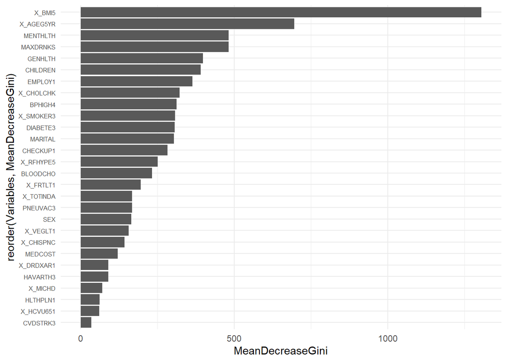

```r
importance <- as.data.frame(importance(BRFS.rf))
importance$Variables <- rownames(importance)

ggplot(importance, aes(x = reorder(Variables, MeanDecreaseGini), y = MeanDecreaseGini)) +
  geom_bar(stat = "identity") +
  coord_flip() +
  theme_minimal() +
  theme(axis.text.y = element_text(size = 6))
```

From the chart, it is evident that X_BMI5 (Body Mass Index) is the most significant predictor of high blood cholesterol, as indicated by its high Mean Decrease Gini value, which is a measure used assess how much a specific feature decrease the impurity of the model. Other significant variables include age and maximum drinks consumed, indicating the importance of lifestyle factors in affecting cholesterol risk.

### 3.5.1 Evaluation on Testset

```r
predictions <- predict(BRFS.rf, test)
predictions <- factor(predictions, levels = levels(training$TOLDHI2))

rf.cm <- confusionMatrix(predictions, test$TOLDHI2)

accuracy <- rf.cm$overall['Accuracy']
kappa <- rf.cm$overall['Kappa']
pos_acc <- rf.cm$byClass['Pos Pred Value']
neg_acc <-rf.cm$byClass['Neg Pred Value']

print(paste("Overall Accuracy:", accuracy))
```

```
## [1] "Overall Accuracy: 0.795426795426795"
```

```r
print(paste("Positive Accuracy:", pos_acc))
```

```
## [1] "Positive Accuracy: 0.817678878780428"
```

```r
print(paste("Negative Predictive Value:", neg_acc))
```

```
## [1] "Negative Predictive Value: 0.588571428571429"
```

```r
print(paste("Kappa:", kappa))
```

```
## [1] "Kappa: 0.258316706018759"
```

### 3.5.2 Parameter tuning

```r
set.seed(5003)
k <- 5  # Number of folds
folds <- createFolds(training$TOLDHI2, k = k, list = TRUE)

mtry_values <- c(3, 7, 15)
ntree_values <- c(100, 500, 1000)

models <- list()
model_info <- vector("list", length = length(mtry_values) * length(ntree_values))

index <- 1

for (m in mtry_values) {
    for (n in ntree_values) {
        accuracies <- numeric(k)
        f1_scores <- numeric(k)

        for (i in 1:k) {
            training_indices <- unlist(folds[-i])
            validation_indices <- folds[[i]]
            train_data_fold <- training[training_indices, ]
            valid_data_fold <- training[validation_indices, ]

            # Train model with specific mtry and ntree
            model <- randomForest(TOLDHI2 ~ ., data = train_data_fold, mtry = m, ntree = n)
            models[[index]] <- model

            # Validate the model on the validation set
            predictions_fold <- predict(model, valid_data_fold)
            cm <- confusionMatrix(as.factor(predictions_fold), as.factor(valid_data_fold$TOLDHI2))
            accuracies[i] <- cm$overall['Accuracy']
        }

        model_info[[index]] <- list(mtry = m, ntree = n, Accuracy = mean(accuracies))
        index <- index + 1
    }
}

# Identify the best model based on the highest average accuracy
accuracies <- sapply(model_info, function(x) x$Accuracy)
best_model_index <- which.max(accuracies)
best_model <- models[[best_model_index]]
best_settings <- model_info[[best_model_index]]

# Output best model settings
print(paste("Best mtry:", best_settings$mtry))
```

```
## [1] "Best mtry: 3"
```

```r
print(paste("Best ntree:", best_settings$ntree))
```

```
## [1] "Best ntree: 500"
```

```r
print(paste("Best Accuracy:", best_settings$Accuracy))
```

```
## [1] "Best Accuracy: 0.8022125072255"
```

### 3.5.3 CV on best parameters

```r
set.seed(5003)
k <- 5  # Number of folds

folds <- createFolds(training$TOLDHI2, k = k, list = TRUE)

accuracies <- numeric(k)

models <- list()

for (i in 1:k) {
    training_indices <- unlist(folds[-i])
    validation_indices <- folds[[i]]
    train_data_fold <- training[training_indices, ]
    valid_data_fold <- training[validation_indices, ]

    models[[i]] <- randomForest(TOLDHI2 ~ ., data = train_data_fold, ntree = 500, mtry = 3)

    # Validate the model on validation set
    predictions_fold <- predict(models[[i]], valid_data_fold)
    cm <- confusionMatrix(as.factor(predictions_fold), as.factor(valid_data_fold$TOLDHI2))
    accuracies[i] <- cm$overall['Accuracy']

    print(paste("Fold", i, "Validation Accuracy:", accuracies[i]))
}
```

```
## [1] "Fold 1 Validation Accuracy: 0.803145235892692"
## [1] "Fold 2 Validation Accuracy: 0.804846466888642"
## [1] "Fold 3 Validation Accuracy: 0.802626711061783"
## [1] "Fold 4 Validation Accuracy: 0.797262301146874"
## [1] "Fold 5 Validation Accuracy: 0.799667036625971"
```

```r
best_model_index <- which.max(accuracies)
best_model <- models[[best_model_index]]

# Evaluate the best model on the test set
final_predictions <- predict(best_model, test)
final_predictions <- factor(final_predictions, levels = levels(training$TOLDHI2))

final_cm <- confusionMatrix(final_predictions, test$TOLDHI2)
final_accuracy <- final_cm$overall['Accuracy']
kappa <- final_cm$overall['Kappa']
pos_acc <- final_cm$byClass['Pos Pred Value']
neg_acc <- final_cm$byClass['Neg Pred Value']

print(paste("Best Model Index:", best_model_index))
```

```
## [1] "Best Model Index: 2"
```

```r
print(paste("Final Accuracy on Test Set:", final_accuracy))
```

```
## [1] "Final Accuracy on Test Set: 0.793983793983794"
```

```r
print(paste("Positive Accuracy on Test Set:", pos_acc))
```

```
## [1] "Positive Accuracy on Test Set: 0.809684008170131"
```

```r
print(paste("Negative Accuracy on Test Set:", neg_acc))
```

```
## [1] "Negative Accuracy on Test Set: 0.603498542274052"
```

```r
print(paste("Kappa on Test Set:", kappa))
```

```
## [1] "Kappa on Test Set: 0.22007640317367"
```

# 4 Model Performance Comparison:

```r
model_metrics <- data.frame(
  Model = c("Logistic Regression", "Bayes", "Random Forest", "SVM"),
  Accuracy = c(0.7969, 0.7894, 0.793983793983794, 0.7901),
  Positive_Accuracy = c(0.8164, 0.8379593, 0.809684008170131, 0.8025290),
  Negative_Accuracy = c(0.6022, 0.5349965, 0.603498542274052, 0.5978062),
  Kappa = c(0.2547, 0.3227, 0.22007640317367, 0.1787)
)
knitr::kable(model_metrics, format = "markdown")
```

[output not shown]

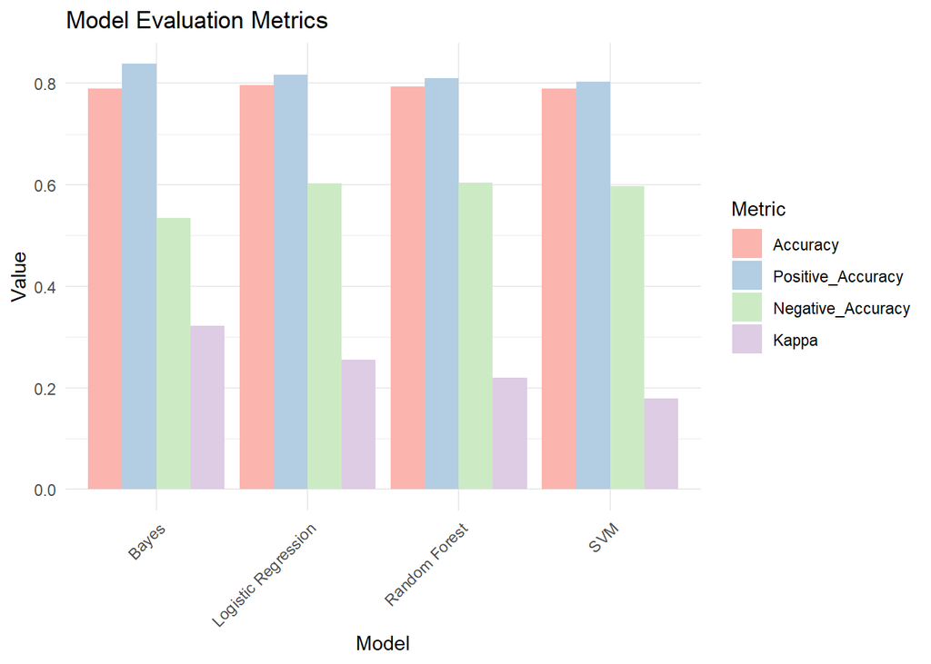

```r
# Plot using ggplot
library(ggplot2)
long_data <- reshape2::melt(model_metrics, id.vars = "Model")

plot <- ggplot(long_data, aes(x = Model, y = value, fill = variable)) +
  geom_bar(stat = "identity", position = "dodge") +
  theme_minimal() +
  labs(title = "Model Evaluation Metrics",
       x = "Model",
       y = "Value",
       fill = "Metric") +
  scale_fill_brewer(palette = "Pastel1") +
  theme(axis.text.x = element_text(angle = 45, hjust = 1))

# Display plot
print(plot)
```

The table and barplot above demonstrate the model comparison of four machine learning models—Logistic Regression, Bayes, Random Forest, and SVM based on their performance metrics:

**Accuracy**: Measures the overall correctness of the model.

**Positive Accuracy**: Indicates the proportion of positive identifications that were actually correct.

**Negative Accuracy**: Indicates the proportion of negative identifications that were actually correct.

**Kappa**: A statistic that measures inter-rater agreement for qualitative items.

# 5 Conclusion

By viewing the final values of the predictions, the high positive accuracy that indicates the model has efficiently predicted the positive class while the poor performance of predictions on the negative class. From the previous confusion matrixes, it is seen that the total number of class 0 is 7011 and total number for class 1 is 1999. The imbalance of the dataset results the performance differences for each class. The models are biased towards predicting positives, likely influenced by the high prevalence of positive cases in the data set. This could be explained by the very high sensitivity (or recall) but very low specificity. The improvements for further analysis or progress consider the resampling of samples or adjusting decision thresholds. For example, use 0.5 as a threshold, but this can be adjusted to be more or less stringent based on the cost of false positives versus false negatives.

The ROC curves for Logistic regression and SVM increase sharply at the beginning. It is a typical performance that classification models could classify positive and negative samples effectively though small change in the threshold leads to a significant increase in the predictions for the True Positive Rate (sensitivity) while modestly increasing predictions for the False Positive Rate. However, when the line reaches a threshold, the curve rises more gradually so indicates diminishing classifier performance. The upper curve could potentially indicate the imbalance of samples for each class.

The positive class is class 0 and indicates the class of “No”. The answers from subjects of the survey have many answers as “No”, regarding the question: “Have you EVER been told by a doctor, nurse, or another health professional that your blood cholesterol is high”, In future research, the allowance from subjects’ digital informatics for medical examinations’ records could be much more accurate than directly ask questions like this. Some people say no doesn’t mean they don’t have high cholesterol. The access to people’s health records would be more helpful to do the analysis and predictions for investigations of what life habits or characteristics of patients will cause high cholesterol. However, it might relate to information security.

# 6 Appendix

## 6.1 Reference

[1] Behavioral Risk Factor Surveillance System (BRFSS). (2016). 2015 Codebook Report: Land-Line and Cell-Phone Data. https://www.cdc.gov/brfss/annual_data/2015/pdf/codebook15_llcp.pdf

[2] Victoria State Government. (2022). Cholesterol. https://www.betterhealth.vic.gov.au/health/conditionsandtreatments/cholesterol

## 6.2 Author contributions

Rayne Zhu 530551405: All members contribute equally to all aspects of this project.

Shenglong Huang 480185790: All members contribute equally to all aspects of this project.

Clark Xiong 490215441: All members contribute equally to all aspects of this project.

Chenghao Xia 530774428: All members contribute equally to all aspects of this project.

Tian Yang530220904: All members contribute equally to all aspects of this project.

Ziqi Long 480057523: All members contribute equally to all aspects of this project.